# Unusable models: when a model does not have a maximum likelihood

Daniel C. Reuman

2026-04-29

Abstract

When an xsdm model does not have a maximum likelihood, it should not be used. This document shows an example of how that can occur, and how to diagnose it. Along the way, another type of boundary model (in addition to the $p_d=1$ case described elsewhere) is illustrated, where sigma parameters are set to infinity, corresponding to insensitivity of annual net growth to environmental changes in a certain direction in environment space.

The Eastern glass lizard, *Ophisaurus ventralis*, is a legless lizard found in the southeastern United States. It is the longest and heaviest species of its genus, growing up to 108cm in total length.

We start by loading the data:

```r
library(xsdm)
env_array <-  example_2$env_array

#We divide by 100 to get the correct units in the example
env_array <-  example_2$env_array/100
dim(env_array)
```

```
## [1] 2728   39    6
```

```r
dimnames(env_array)[[3]]
```

[output not shown]

```r
occ <-  example_2$occ_vec
length(occ)
```

```
## [1] 2728
```

Here, there are 6 environmental variables recorded for 39 years in 2728 locations, with accompanying detections and pseudo-absences in the variable `occ`. The first three environmental variables (BIO1, BIO10, BIO11) are temperature variables, and the last three (BIO12, BIO16, BIO17) are precipitation variables. BIO1 is mean annual temperature, BIO10 is mean temperature of the warmest quarter, BIO11 is mean temperature of the coldest quarter, BIO12 is annual precipitation, BIO16 is precipitation of the wettest quarter, and BIO17 is precipitation of the driest quarter.

Now look at the distributions of values of environmental variables to make sure they are not on very different scales, which would cause problems for optimization:

```r
apply(FUN=quantile, X=env_array, MARGIN=3,prob=c(.025,.25,.5,.75,.975))
```

```
##        [,1]  [,2]  [,3]   [,4]  [,5]  [,6]
## 2.5%  12.21 21.39  3.84  88.08 10.14  2.21
## 25%   16.87 25.76  8.88 114.44 14.34  4.36
## 50%   18.71 26.63 11.52 131.57 17.40  5.77
## 75%   20.42 27.33 14.38 151.15 20.91  7.22
## 97.5% 24.29 28.29 20.72 195.81 29.55 10.72
```

These distributions look basically OK.

Now fit 15 models, each from 25 starting conditions:

```r
models = matrix(c(1,0,0,0,0,0,
                  0,1,0,0,0,0,
                  0,0,1,0,0,0,
                  0,0,0,1,0,0,
                  0,0,0,0,1,0,
                  0,0,0,0,0,1,
                  1,0,0,1,0,0,
                  1,0,0,0,1,0,
                  1,0,0,0,0,1,
                  0,1,0,1,0,0,
                  0,1,0,0,1,0,
                  0,1,0,0,0,1,
                  0,0,1,1,0,0,
                  0,0,1,0,1,0,
                  0,0,1,0,0,1), nrow=15, byrow=TRUE)
all_model_results = list()
for (i in 1:nrow(models))
{
  print(i)
  env_dat <-  env_array[ , , models[i,]==1, drop = FALSE]
  starts <-  xsdm::start_parms(env_dat,num_starts=25)
  all_optim_results <-  list()
  for (j in 1:nrow(starts))
  {
    all_optim_results[[j]] <-  optim(par = starts[j,],
                                   fn = xsdm::loglik_math,
                                   method = "BFGS",
                                   env_dat = env_dat,
                                   occ = occ,
                                   negative=TRUE,
                                   control = list(trace=0)
                                   )
  }
  all_model_results[[i]] = all_optim_results
}
```

```
## [1] 1
## [1] 2
## [1] 3
## [1] 4
## [1] 5
## [1] 6
## [1] 7
## [1] 8
## [1] 9
## [1] 10
## [1] 11
## [1] 12
## [1] 13
## [1] 14
## [1] 15
```

Within each model, rank the optimization results:

```r
for (i in 1:length(all_model_results))
{
  values <-  sapply(X = all_model_results[[i]], FUN=function(x){x$value})
  inds <-  order(values)
  all_model_results[[i]] <-  all_model_results[[i]][inds]
}
```

Rank the models by BIC, bearing in mind that we’ve been working with the negative of the likelihood:

```r
model_BICs = sapply(X=all_model_results,
                      FUN=function(x){
                        best_loglik = x[[1]]$value
                        num_parms = length(x[[1]]$par)
                        n = length(occ)
                        BIC = 2*best_loglik + num_parms*log(n)
                        return(BIC)
                      }
                    )
```

Also by AIC, then display:

```r
model_AICs = sapply(X=all_model_results,
                      FUN=function(x){
                        best_loglik = x[[1]]$value
                        num_parms = length(x[[1]]$par)
                        AIC = 2*best_loglik + 2*num_parms
                        return(AIC)
                      }
                    )

inds = order(model_BICs)
rbind(model_BICs[inds],model_AICs[inds])
```

```
##          [,1]     [,2]     [,3]     [,4]     [,5]     [,6]     [,7]     [,8]
## [1,] 2419.974 2473.686 2482.668 2550.380 2580.196 2586.113 2593.665 2595.839
## [2,] 2366.772 2420.484 2429.466 2520.824 2550.639 2556.556 2540.463 2542.637
##          [,9]    [,10]    [,11]    [,12]    [,13]    [,14]    [,15]
## [1,] 2598.226 2602.630 2604.562 2676.690 2683.086 2915.412 2945.965
## [2,] 2545.024 2549.428 2551.360 2647.133 2629.884 2885.855 2916.408
```

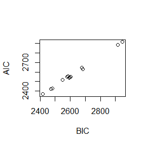

```r
plot(model_BICs,model_AICs,type="p",xlab="BIC",ylab="AIC")
```

```r
order(model_BICs)
```

```
##  [1] 11  8 14  5  3  1 13 15  7 10  9  2 12  4  6
```

```r
order(model_AICs)
```

```
##  [1] 11  8 14  5 13 15  7 10  3  9  1 12  2  4  6
```

The AIC and BIC results are pretty well aligned, and the four best models are the same:

```r
models[order(model_BICs)[1:4],]
```

```
##      [,1] [,2] [,3] [,4] [,5] [,6]
## [1,]    0    1    0    0    1    0
## [2,]    1    0    0    0    1    0
## [3,]    0    0    1    0    1    0
## [4,]    0    0    0    0    1    0
```

These four models all use the same predictor, the fifth one, and then some use various possible second predictors.

We emphasize that these BIC and AIC values may or may not be meaningful, since B/AIC can only be computed when the likelihood has been effectively maximized. We will elaborate below, but for now we accept these are pseudo-BIC and pseudo-AIC values, subject to later validation or rejection.

Among the models we fitted, there is one clear winner in pseudo-BIC, model 11. So let’s investigate it further. Start by optimizing it a bit harder to see if we can do any better.

```r
i = 11
env_dat = env_array[,,models[i,]==1,drop=FALSE]
starts = xsdm::start_parms(env_dat, num_starts = 100)
model_11_results = list()
for (j in 1:nrow(starts))
{
  model_11_results[[j]] = optim(par=starts[j,],fn=xsdm::loglik_math,
                                method="BFGS",
                                env_dat = env_dat,
                                occ = occ,negative=TRUE,
                                control = list(trace=0))
}
all_model_results[[11]][[1]]$value
```

```
## [1] 1174.386
```

```r
min(sapply(X=model_11_results, FUN=function(y){y$value}))
```

```
## [1] 1174.272
```

We did slightly better.

Now move forward by looking at the results for this model, starting by writing a convenience function for examine optimization results:

```r
examine_optim_results = function(optim_results,mask=NULL)
{
  #put optimization results in order from best to worst
  bestlogliks = sapply(X=optim_results,FUN=function(x){x$value})
  inds = order(bestlogliks)
  bestlogliks = bestlogliks[inds]
  optim_results = optim_results[inds]

  #model convergence
  convergences = sapply(X=optim_results,FUN=function(x){x$convergence})

  #compute distances to the best result in parameter space
  best_parms_math = optim_results[[1]]$par
  parms_dists_to_best = lapply(
    X=optim_results,
    FUN=function(x){
      xsdm::dist_between_params(
        x$par,
        best_parms_math,
        mask=mask,
        give_closest_rep=TRUE)
    }
  )
  parms_dists = sapply(X=parms_dists_to_best, FUN=function(x){x$distance})
  bestparms=sapply(X=parms_dists_to_best, FUN=function(x){unlist(x$representative)})

  #put it all together
  return(rbind(bestlogliks,convergences,parms_dists,bestparms))
}

h <- examine_optim_results(all_model_results[[11]])
t(h[ ,1:8])
```

```
##      bestlogliks convergences parms_dists      mu1      mu2  sigltil1 sigltil2
## [1,]    1174.386            0    0.000000 29.43182 47.41188 0.6350120 6.601980
## [2,]    1174.457            1    1.324798 29.34740 46.12003 0.6330502 6.421509
## [3,]    1174.497            1    1.740402 29.31220 45.72477 0.6334546 6.359638
## [4,]    1174.498            1    2.992901 29.20125 44.62455 0.6442207 6.316051
## [5,]    1174.588            0    5.466302 29.05863 42.28859 0.6432049 6.047886
## [6,]    1174.623            1    5.133477 29.06440 42.57833 0.6428971 6.064849
## [7,]    1174.742            0    8.261670 28.85794 39.63766 0.6447833 5.712791
## [8,]    1174.834            1    8.948450 28.85149 38.92282 0.6349000 5.572258
##       sigrtil1    sigrtil2       ctil        pd    o_mat1      o_mat2
## [1,] 0.3226539    164.7399 -12.499904 0.5416640 0.9964337 -0.08437974
## [2,] 0.3231649   1221.1511 -12.218838 0.5408277 0.9963480 -0.08538547
## [3,] 0.3263350  47722.9537 -12.091204 0.5395633 0.9963234 -0.08567251
## [4,] 0.3198812 304712.1909 -11.435114 0.5437206 0.9964682 -0.08397064
## [5,] 0.3214653    650.2904 -10.631141 0.5451221 0.9962723 -0.08626470
## [6,] 0.3210981    116.1511 -10.810649 0.5447610 0.9963409 -0.08546875
## [7,] 0.3214255    929.1494  -9.763832 0.5458316 0.9961687 -0.08745185
## [8,] 0.3257750    197.0317  -9.730062 0.5438346 0.9958564 -0.09093919
##          o_mat3    o_mat4
## [1,] 0.08437974 0.9964337
## [2,] 0.08538547 0.9963480
## [3,] 0.08567251 0.9963234
## [4,] 0.08397064 0.9964682
## [5,] 0.08626470 0.9962723
## [6,] 0.08546875 0.9963409
## [7,] 0.08745185 0.9961687
## [8,] 0.09093919 0.9958564
```

So we consider the corresponding boundary model:

```r
i <- 11
env_dat = env_array[ , , models[i,] == 1, drop=FALSE]
mask <- c(sigltil2 = Inf)
new_starts = xsdm::start_parms(env_dat[occ == 1, , , drop=FALSE],
                               mask = mask,
                               num_starts = 100)

bdry_optim_results = list()
for (j in 1:nrow(new_starts))
{
  bdry_optim_results[[j]] = optim(par = new_starts[j,],
                                  fn = xsdm::loglik_math,
                                  method = "BFGS",
                                  env_dat = env_dat,
                                  occ = occ,
                                  mask = mask,
                                  negative = TRUE,
                                  control = list(trace=0, maxit=500))
}
```

Now look at these results:

```r
h <- examine_optim_results(bdry_optim_results, mask = mask)
t(h[ ,1:8])
```

```
##      bestlogliks convergences parms_dists      mu1      mu2  sigltil1 sigltil2
## [1,]    1174.333            0    0.000000 29.60954 49.88920 0.3178785      Inf
## [2,]    1174.387            0    2.619499 29.42940 47.35555 0.3220420      Inf
## [3,]    1174.404            0    2.974921 29.40007 47.04255 0.3181946      Inf
## [4,]    1174.405            0    2.517225 29.39857 47.43582 0.3221701      Inf
## [5,]    1174.415            0    3.472687 29.36961 46.55657 0.3198252      Inf
## [6,]    1174.450            0    4.456654 29.28353 45.63060 0.3240391      Inf
## [7,]    1174.454            0    4.777032 29.28358 45.34363 0.3230825      Inf
## [8,]    1174.471            0    5.225465 29.26301 44.91290 0.3183499      Inf
##       sigrtil1 sigrtil2      ctil        pd     o_mat1     o_mat2      o_mat3
## [1,] 0.6468369 6.928698 -13.10346 0.5437772 -0.9965750 0.08269385 -0.08269385
## [2,] 0.6356462 6.600291 -12.46512 0.5421500 -0.9964332 0.08438574 -0.08438574
## [3,] 0.6451817 6.587212 -12.26513 0.5429547 -0.9964929 0.08367710 -0.08367710
## [4,] 0.6346613 6.582443 -12.58373 0.5409020 -0.9965286 0.08325090 -0.08325090
## [5,] 0.6411237 6.519074 -12.15746 0.5426516 -0.9964426 0.08427469 -0.08427469
## [6,] 0.6349977 6.419805 -11.83253 0.5429959 -0.9964169 0.08457780 -0.08457780
## [7,] 0.6387804 6.404600 -11.67222 0.5439628 -0.9963636 0.08520269 -0.08520269
## [8,] 0.6447644 6.349975 -11.54733 0.5434082 -0.9963662 0.08517279 -0.08517279
##          o_mat4
## [1,] -0.9965750
## [2,] -0.9964332
## [3,] -0.9964929
## [4,] -0.9965286
## [5,] -0.9964426
## [6,] -0.9964169
## [7,] -0.9963636
## [8,] -0.9963662
```

The best likelihoods obtained for this boundary model are very similar to those obtained for the initial, non-boundary model, and the boundary model has one fewer parameter, so we tentatively adopt the boundary model over the earlier model. However, these optimization results reveal that we probably still have not successfully optimized the likelihood, or that the likelihood surface may have a ridge or an asymptote or other pathological feature. One sees this by observing that whereas the top several optimization results are similar in likelihood, they are spread out in parameter space (the `parms_dists` column shows distance in parameter space to the top-likelihood result).

To investigate the model further, we profile:

```r
pnames <-  names(xsdm::make_mask_names(2))
pnames <-  pnames[!(pnames %in% names(mask))]

values <-  sapply(X=bdry_optim_results, FUN=function(x){x$value})
inds <-  order(values)
bdry_optim_results <-  bdry_optim_results[inds]

all_profiles=list()
linc <-  rep(0.05, length(pnames))
rinc <-  rep(0.05, length(pnames))
linc[8] <-  0.001
rinc[8] <-  0.001
for (counter in 1:length(pnames))
{
  all_profiles[[counter]] <-  xsdm::profile_likelihood(
                              profile_parameter = pnames[counter],
                              increment_left =linc[counter],
                              increment_right = rinc[counter],
                              num_steps_left = 50,
                              num_steps_right = 50,
                              alpha = 0.95,
                              optim_param_vector = bdry_optim_results[[1]]$par,
                              env_dat=env_dat,
                              occ = occ,
                              mask = mask,
                              num_threads = 6
                            )
}
names(all_profiles) <-  pnames
```

Now plot these profiles:

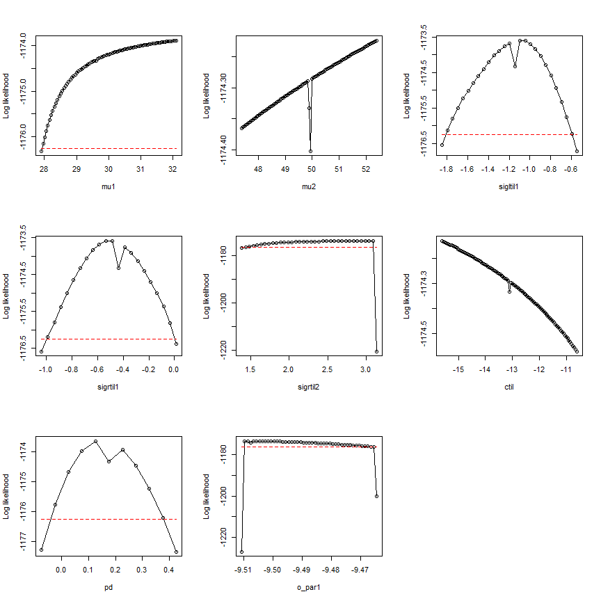

```r
plot_tool <- function(ap,index)
  {
  x <- ap[[index]]$profile$value_math
  y <- ap[[index]]$profile$loglik
  xlab <- names(ap)[index]
  thresh <- ap[[index]]$threshold
  plot(x,y,
       type="o",xlab=xlab,
       ylab="Log likelihood")
  lines(range(x),rep(thresh,2),type="l",
        lty="dashed",col="red")
}

par(mfrow=c(3,3))
plot_tool(all_profiles, 1)
plot_tool(all_profiles, 2)
plot_tool(all_profiles, 3)
plot_tool(all_profiles, 4)
plot_tool(all_profiles, 5)
plot_tool(all_profiles, 6)
plot_tool(all_profiles, 7)
plot_tool(all_profiles, 8)
```

These profiles are not dome-shaped, and have other idiosyncratic features, confirming that we had not effectively optimized the likelihood. The `mu2`, `mu2`, and `ctil` profile, in particular, show problems.

We do a pairs plot based on the `mu2` profile to investigate further:

```r
p <- all_profiles[[2]]$parameters
head(p)
```

```
##        mu1     mu2  sigltil1   sigrtil1 sigrtil2      ctil        pd    o_par1
## 1 29.52907 47.3892 -1.128260 -0.4545133 1.893549 -12.36849 0.1748123 -9.512550
## 2 29.53320 47.4392 -1.128232 -0.4545836 1.894381 -12.38544 0.1747639 -9.512543
## 3 29.53733 47.4892 -1.128204 -0.4546531 1.895212 -12.40239 0.1747163 -9.512537
## 4 29.54146 47.5392 -1.128176 -0.4547223 1.896041 -12.41935 0.1746688 -9.512530
## 5 29.54559 47.5892 -1.128147 -0.4547921 1.896869 -12.43630 0.1746214 -9.512524
## 6 29.54972 47.6392 -1.128120 -0.4548609 1.897695 -12.45325 0.1745745 -9.512517
##   sigltil2
## 1      Inf
## 2      Inf
## 3      Inf
## 4      Inf
## 5      Inf
## 6      Inf
```

[figure not shown]

```r
p <- p[,1:8]
pairs(p)
```

This pairs plot helps us see the tradeoff going on between parameters. As `mu2` is increased, other parameters, especially `ctil`, change monotonically. These results suggest a ridge in the likelihood surface that appears to rise asymptotically along some path in parameter space for which `mu2` is increasing. We have not identified a maximum of the likelihood function, and it looks as though there may not be one if the increase is indeed asymptotic.

We look at what the growth-environment function looks like for the best parameters we have found so far, maybe that will give some insight into what is going wrong:

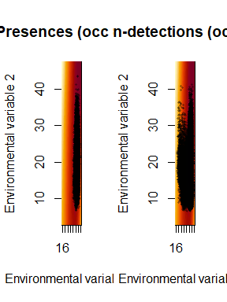

```r
param_list = bdry_optim_results[[1]]$par
param_list["sigltil2"] = Inf
param_list = param_list[names(xsdm::make_mask_names(2))]
param_list_bio = xsdm::math_to_bio(param_list)
xsdm::interpret_parameters(param_list = param_list_bio,
                          plot_indices = c(1,2), env_dat=env_dat, occ = occ)
```

```r
param_list_bio$mu
```

```
## [1] 29.60954 49.88920
```

Estimated values of `mu2` are outside the range of the environmental data. The actual distribution of the species is across Florida and along the coasts of the Southeastern United States, and the southern extent of the species is very likely constrained, on the southern end of the range, by the Atlantic Ocean and the Gulf of Mexico rather than by temperature and precipitation. Ultimately the modeling probably fails here for these reasons. A Bayesian approach to the same problem could likely address some of the limitations, here, by setting appropriate priors. In the frequentist setting, one must discard the model. AIC and BIC values are invalid when the likelihood has not been adequately optimized and when the likelihood surface in the vicinity of the optimum is not approximately a dome.

Immediate next steps should include examination of models 8 and 14, which were the next-best models according to pseudo-BIC, to see if they have similar problems. For brevity and because we are just trying to illustrate statistical principles and workflows, we skip straight to examining model 5, which may be simpler because it only uses one environmental variable.

```r
i=5
model_5_optim_results <-  all_model_results[[i]]
h <- examine_optim_results(model_5_optim_results)
t(h[,1:8])
```

```
##      bestlogliks convergences  parms_dists       mu  sigltil      sigrtil
## [1,]    1255.412            0 0.0000000000 21.32529 2.399255 2.937853e+06
## [2,]    1255.412            0 0.0004469575 21.32563 2.399293 2.169292e+10
## [3,]    1255.412            0 0.0018557626 21.32677 2.399653 9.219196e+02
## [4,]    1255.412            0 0.0029701192 21.32678 2.399668 3.905636e+02
## [5,]    1255.412            0 0.0046965876 21.32545 2.399292 2.130359e+02
## [6,]    1255.412            0 0.0053307789 21.32748 2.399726 2.089304e+02
## [7,]    1255.412            0 0.0054598701 21.32548 2.399325 1.833251e+02
## [8,]    1255.412            0 0.0124666400 21.33611 2.401907 1.894162e+02
##           ctil        pd o_mat
## [1,] -1.806417 0.6390113     1
## [2,] -1.806707 0.6389671     1
## [3,] -1.806725 0.6389960     1
## [4,] -1.806654 0.6390159     1
## [5,] -1.806391 0.6390457     1
## [6,] -1.807263 0.6389515     1
## [7,] -1.806277 0.6390752     1
## [8,] -1.809611 0.6387623     1
```

One can see the boundary model with `sigrtil` set to `Inf` should be considered:

```r
env_dat = env_array[,,models[i,]==1,drop=FALSE]
mask=c(sigrtil1 = Inf)
new_starts = xsdm::start_parms(env_dat[occ==1,,,drop=FALSE],mask=mask,
                               num_starts=100)

bdry_optim_results5 = list()
for (j in 1:nrow(new_starts))
{
  bdry_optim_results5[[j]] = optim(par=new_starts[j,],fn=xsdm::loglik_math,
                                method="BFGS",
                                env_dat=env_dat,occ=occ,mask=mask,negative=TRUE,
                                control=list(trace=0,maxit=500))
}
```

Examine these results:

```r
h <- examine_optim_results(bdry_optim_results5,mask=mask)
t(h[,1:8])
```

```
##      bestlogliks convergences  parms_dists       mu  sigltil sigrtil      ctil
## [1,]    1255.412            0 0.0000000000 21.32484 2.399158     Inf -1.806229
## [2,]    1255.412            0 0.0003131745 21.32509 2.399190     Inf -1.806409
## [3,]    1255.412            0 0.0001353068 21.32497 2.399183     Inf -1.806271
## [4,]    1255.412            0 0.0001059360 21.32477 2.399108     Inf -1.806307
## [5,]    1255.412            0 0.0005280171 21.32531 2.399243     Inf -1.806466
## [6,]    1255.412            0 0.0005118553 21.32530 2.399250     Inf -1.806441
## [7,]    1255.412            0 0.0005093753 21.32530 2.399253     Inf -1.806431
## [8,]    1255.412            0 0.0005184385 21.32531 2.399247     Inf -1.806447
##             pd o_mat
## [1,] 0.6390291     1
## [2,] 0.6390088     1
## [3,] 0.6390267     1
## [4,] 0.6390219     1
## [5,] 0.6390059     1
## [6,] 0.6390094     1
## [7,] 0.6390097     1
## [8,] 0.6390102     1
```

```r
values = sapply(X=bdry_optim_results5, FUN=function(x){x$value})
inds = order(values)
bdry_optim_results5 = bdry_optim_results5[inds]
```

This model looks like it probably optimized well.

Next do profiles:

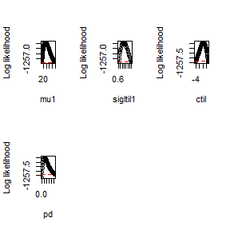

```r
all_profiles <- list()
pnames <- names(xsdm::make_mask_names(1))
pnames = pnames[pnames!="sigrtil1"]
linc = c(0.05,0.025,0.05,0.05)
rinc = c(0.15,0.025,0.05,0.05)
for (counter in 1:length(pnames))
{
  all_profiles[[counter]] <-  xsdm::profile_likelihood(
                              profile_parameter = pnames[counter],
                              increment_left  = linc[counter],
                              increment_right = rinc[counter],
                              num_steps_left  = 50,
                              num_steps_right = 50,
                              alpha = 0.95,
                              optim_param_vector = bdry_optim_results5[[1]]$par,
                              env_dat = env_dat,
                              occ = occ,
                              mask = mask,
                              num_threads = 6
                            )
}
names(all_profiles) = pnames

par(mfrow=c(2,3))
plot_tool(all_profiles,1)
plot_tool(all_profiles,2)
plot_tool(all_profiles,3)
plot_tool(all_profiles,4)
```

The profiles look adequate. So the model is suitable for use, unlike the previous model. The BIC and AIC for this model are valid. If model 8 or 14 is suitable in the same manner, the lowest-BIC model suitable model should tend to be preferred.